# Output of Diff-in-Diff-Replication

#### Preparations for Quarto

```r
packs <- c('knitr', 'tidyverse', 'fixest', 'tinytable', 'modelsummary', 'this.path')

# 1. Check packages without carrying over names
success <- suppressWarnings(sapply(packs, require, character.only = TRUE, USE.NAMES = FALSE))

# 2. Extract failed packages using indexing instead of names
failed_packs <- packs[!success]

# 3. Install missing packages
if (length(failed_packs) > 0) {
  install.packages(failed_packs)

  # 4. Retry loading missing packages without names
  sapply(failed_packs, require, character.only = TRUE, USE.NAMES = FALSE)
}


# set options
options(modelsummary_format_numeric_latex = "plain")
options(tinytable_latex_placement = "H")


# Note current script location
current_script_dir <- this.path::this.dir()
# cat("Script directory:", current_script_dir, "\n")

# Set project root
project_root <-  this.path::this.proj()
opts_knit$set(root.dir = project_root)
# cat("Project root set to:", getwd(), "\n")
```

```r
#' Source specific lines in an R file (from https://gist.github.com/christophergandrud/1eb4e095974204b12af9#file-source_lines-r)
#'
#' @param file character string with the path to the file to source.
#' @param lines numeric vector of lines to source in \code{file}.

source_lines <- function(file, lines){
    source(textConnection(readLines(file)[lines]))
}
```

### View raw data

```r
source_lines(file.path(project_root, "02_rscripts/01_data_cleaning.R"), (20:22))
```

```r
### View some variables:

# table(replication_data$class, exclude = NULL)

replication_data |>
  count(class, .drop = FALSE) |>
  mutate(pct = n / sum(n) * 100)
```

```
# A tibble: 4 × 3
  class                                                                  n   pct
  <dbl+lbl>                                                          <int> <dbl>
1   5 [Euro 4 (si applica ad auto immatricolate tra il 2006 and 201…   415 38.7
2   6 [Euro 5 (si applica ad auto immatricolate tra il 2009 and 201…   291 27.1
3   7 [Euro 6 (si applica ad auto immatricolate dopo il 2014)]         303 28.2
4 999 [Non so / non ricordo]                                            64  5.96
```

```r
# table(replication_data$fuel, exclude = NULL)

replication_data |>
  count(fuel, .drop = FALSE) |>
  mutate(pct = n / sum(n) * 100)
```

```
# A tibble: 3 × 3
  fuel                           n    pct
  <dbl+lbl>                  <int>  <dbl>
1   1 [Diesel]                 555 51.7
2   2 [Benzina]                513 47.8
3 977 [Non so / non ricordo]     5  0.466
```

```r
# table(replication_data$target, exclude = NULL)
replication_data |>
  count(target, .drop = FALSE) |>
  mutate(pct = n / sum(n) * 100)
```

```
# A tibble: 4 × 3
  target                                                                 n   pct
  <dbl+lbl>                                                          <int> <dbl>
1 1 [Treated (Diesel Euro 4 affected by ban)]                          293 27.3
2 2 [Control 1 (Diesel Euro 5 or Petrol Euro 4 or 5 unaffected by b…   412 38.4
3 3 [Control 2 (Diesel Euro 6 or Petrol Euro 6 unaffected by ban)]     303 28.2
4 4 [Car Model Unknown]                                                 65  6.06
```

### Data cleaning

```r
# Source local code

source_lines(file.path(project_root, "02_rscripts/01_data_cleaning.R"), (28:174))
```

Note the variable `target` that is 4 if the car is unknown! (For some it is also 3, which is also not a car in the `groups` variable.)

## To display Table 1 in their paper:

```r
# Source local code

source_lines(file.path(project_root, "02_rscripts/02_descriptives.R"), (31:188))
```

This gives you Table 1.

```r
tab_1 |>
  setNames(c("Variables", "Full Sample",
             "Diesel Euro 4 (Treated)",
             "Diesel Euro 5",
             "Petrol Euro 4",
             "Petrol Euro 5")) |>
style_tt(i = 6, line = "t") |>
  style_tt(i = 8, line = "t") |>
  style_tt(i = 12, line = "t") |>
  style_tt(i = 18, line = "t")
```

Table 1: Descriptive statistics by experimental group

| Variables | Full Sample | Diesel Euro 4 (Treated) | Diesel Euro 5 | Petrol Euro 4 | Petrol Euro 5 |
| --- | --- | --- | --- | --- | --- |
| 18-24 | 2.7 | 1.4 | 1.7 | 2.5 | 2.4 |
| 25-34 | 10.8 | 6.1 | 13.3 | 15.6 | 19.4 |
| 35-44 | 34.7 | 43.3 | 21.7 | 32 | 23.5 |
| 45-54 | 31.3 | 42 | 35 | 23 | 26.5 |
| 55+ | 20.5 | 7.2 | 28.3 | 27 | 28.2 |
| Male | 52 | 69 | 62 | 43 | 45 |
| Female | 48 | 31 | 38 | 57 | 55 |
| High school diploma | 33.74 | 16.04 | 36.67 | 48.36 | 41.2 |
| Bachelors | 27.21 | 30.72 | 27.5 | 22.95 | 27.1 |
| MA or higher | 38.49 | 52.56 | 35 | 27.87 | 30.6 |
| Unknown | 0.56 | 0.68 | 0.83 | 0.82 | 1.2 |
| Less than 14.999 EUR per year | 6.9 | 4.4 | 5.8 | 18.9 | 12 |
| From 15.000 EUR to 29.999 EUR per year | 20.3 | 7.8 | 24.2 | 29.5 | 30 |
| From 30.000 EUR to 44.999 EUR per year | 21.7 | 30 | 16.7 | 19.7 | 21 |
| From 45.000 EUR 69.999 EUR per year | 14.9 | 14.7 | 20.8 | 9 | 13 |
| From 70.000 EUR and more | 26.8 | 38.6 | 20 | 5.7 | 12 |
| No Answer / DK | 9.3 | 4.4 | 12.5 | 17.2 | 12 |
| N | 1073 | 293 | 120 | 122 | 170 |

In sum, there are 1073 respondents but car info for the treatment group (Diesel-Euro4, n=293) and the three control group car types (Diesel-Euro5 (n=120), Petrol-Euro4 (n=122), and Petrol-Euro5 (n=170)) is only available for 705 (= 293 + 120 + 122 + 170), which is 65.7% of their “*Full Sample*”.

## Preparing the Diff-in-Diffs:

“*In selecting these four groups, our aim is to compare affected car owners to owners of relatively similar-yet-unaffected cars. We do so by estimating difference-in-differences specifications of the following form:*

$$Outcome_i = \alpha + \beta Diesel_i + \gamma Euro4_i + \delta Diesel \times Euro4_{i} + \theta X_i + \epsilon_i$$

*where* $_i$ *denotes individual respondents, Outcome is either vote choice or individual attitudes and behavior.*” (Colantone et al. 2024, 113)

Therefore, the most relevant variables needed are `vote_lega_euro` as the outcome, `dummy_diesel`, `dummy_euro_4` (which allows us to create`dummy_diesel`$\times$`dummy_euro_4`). Additionally, for $X$, this would be for `age`, `female`, `education`, `income`, `vote_lega_2018`, `vote_lega_regional`, and `vote_lega_municipal`, following the Table 2 footnote in Colantone et al. (2024).

### Let’s try the regressions from their Table 2:

```r
# Similar to their table 1, make Petrol Euro 5 the omitted group
data$cargroup <- relevel(as.factor(data$groups), "Petrol Euro 5")

# Estimate
basic_model <- lm(vote_lega_euro ~ cargroup  , data = data)

# Nicer labels
my_coef_map <- c(
  "cargroupDiesel Euro 4" = "Diesel EURO 4",
  "cargroupDiesel Euro 5" = "Diesel EURO 5",
  "cargroupPetrol Euro 4" = "Petrol EURO 4",
  "(Intercept)" = "Constant"
)

# output using modelsummary
modelsummary(
  basic_model,
  vcov = "robust",
  coef_map = my_coef_map,
  stars = TRUE,
  width = 1,
  gof_omit = 'AIC|BIC|Log.Lik|F|RMSE' ,
  escape = FALSE
)
```

Table 2: The most basic diff-in-diff regression

|  | (1) |
| --- | --- |
| Diesel EURO 4 | 0.031 |
|  | (0.040) |
| Diesel EURO 5 | -0.062 |
|  | (0.046) |
| Petrol EURO 4 | -0.031 |
|  | (0.047) |
| Constant | 0.212*** |
|  | (0.032) |
| Num.Obs. | 705 |
| R2 | 0.007 |
| R2 Adj. | 0.003 |
| Std.Errors | HC3 |

+ p < 0.1, * p < 0.05, ** p < 0.01, *** p < 0.001

Table 3 gives results (note: I excluded their column 3, given I have no idea what is going on with the `Num. Obs.`).

```r
# Filter out those who are not in any of the cargroups in data$groups
data1 <- data |> filter(!is.na(groups))

#generate a vector of models to be exported
export_models <- list()

# estimate model 1 (similar to above) and save as 1 in the vector
export_models[['1']] <-   lm(vote_lega_euro ~ dummy_diesel * dummy_euro_4,
                            data = data1)

# estimate model 2 (with controls) and save as 2 in the export_models vector
export_models[['2']] <- lm(vote_lega_euro ~ dummy_diesel * dummy_euro_4
                           + age + female + EDU + INC,
                           data = data1)

# estimate model 4 (with controls plus previous LEGA vote in 2018) and save as 4 in the export_models vector
export_models[['4']] <-   lm(vote_lega_euro ~ dummy_diesel * dummy_euro_4
                             + age + female + EDU + INC +
                              vote_lega_2018,
                             data = data1)

# estimate model 5 (with controls plus previous LEGA vote in regional elections) and save as 5 in the export_models vector
export_models[['5']]<-   lm(vote_lega_euro ~ dummy_diesel * dummy_euro_4
                             + age + female + EDU + INC +
                              vote_lega_regional,
                             data = data1)

# estimate model 6 (with controls plus previous LEGA vote in municipal elections) and save as 6 in the export_models vector
export_models[['6']] <- lm(vote_lega_euro ~ dummy_diesel * dummy_euro_4
                                + age + female + EDU + INC +
                                vote_lega_municipal,
                               data = data1)


# generate a tibble with info to be attached to the output table
rows <- tibble::tribble(~term, ~ '1',  ~ '2',  ~ '4',  ~ '5',  ~ '6',
                'Age', '-' ,   'Yes',   'Yes' ,   'Yes' ,   'Yes' ,
                'Female', '-' ,   'Yes',   'Yes' ,   'Yes' ,   'Yes' ,
                'Income', '-' ,   'Yes',   'Yes' ,   'Yes' ,   'Yes' ,
                'Education' , '-' ,   'Yes',   'Yes' ,   'Yes' ,   'Yes' ,
                'Past Lega Vote', '-',   '-', 'L18', 'R18', 'M16'
                )
attr(rows, 'position') <- c(7, 8, 9, 10, 11)


## Export the model

 modelsummary(
  export_models,
  vcov = "robust", # show cluster-and heteroskedasticity robust SEs
coef_omit = "^(?!dummy_)", # only keep dummies.
  stars = TRUE,
  width = 1,
 add_rows = rows,
  gof_omit = 'AIC|BIC|Log.Lik|F|RMSE' ,
escape = FALSE)
```

Table 3: Similar to their Table 2

|  | 1 | 2 | 4 | 5 | 6 |
| --- | --- | --- | --- | --- | --- |
| dummy_diesel | -0.062 | -0.068 | -0.034 | 0.000 | 0.016 |
|  | (0.046) | (0.047) | (0.032) | (0.033) | (0.037) |
| dummy_euro_4 | -0.031 | -0.037 | 0.014 | 0.013 | 0.002 |
|  | (0.047) | (0.050) | (0.033) | (0.032) | (0.036) |
| dummy_diesel × dummy_euro_4 | 0.124* | 0.160* | 0.079+ | 0.074+ | 0.082 |
|  | (0.063) | (0.067) | (0.044) | (0.045) | (0.051) |
| Age | - | Yes | Yes | Yes | Yes |
| Female | - | Yes | Yes | Yes | Yes |
| Income | - | Yes | Yes | Yes | Yes |
| Education | - | Yes | Yes | Yes | Yes |
| Past Lega Vote | - | - | L18 | R18 | M16 |
| Num.Obs. | 705 | 705 | 705 | 705 | 705 |
| R2 | 0.007 | 0.117 | 0.553 | 0.521 | 0.422 |
| R2 Adj. | 0.003 | 0.087 | 0.537 | 0.504 | 0.402 |
| Std.Errors | HC3 | HC3 | HC3 | HC3 | HC3 |

+ p < 0.1, * p < 0.05, ** p < 0.01, *** p < 0.001

In Table 4, different outcome variables (votes for lega in different years) are used, next to the first column, which (again) uses the EU elections of 2019 (as in Table 3) as the DV.

```r
# Filter out those who are not in data$groups
data1 <- data |> filter(!is.na(groups))

# run models using feols from fixest with different depvars (see vector)
mod <- fixest::feols(
  c(
    vote_lega_euro,
    vote_lega_2018,
    vote_lega_regional,
    vote_lega_municipal
  ) ~ i(dummy_diesel, ref = 0) + i(dummy_euro_4, ref = 0) + i(dummy_diesel, dummy_euro_4, ref =
                                                                0) + age + female |  EDU + INC,
  data = data1
)

# give names to each panel using their DV
panels <- list(
  "Euro" = mod[grepl("euro", names(mod))],
  "2018" = mod[grepl("2018", names(mod))],
  "Regional" = mod[grepl("regional", names(mod))],
  "Municipal" = mod[grepl("municipal", names(mod))]
)

modelsummary(
  panels,
  vcov = "robust",
  stars = TRUE,
  width = 1,
  gof_omit = 'AIC|BIC|Log.Lik|F|RMSE' ,
  escape = FALSE
)
```

Table 4: DV is Lega vote in …

|  | Euro | 2018 | Regional | Municipal |
| --- | --- | --- | --- | --- |
| dummy_diesel = 1 | -0.068 | -0.042 | -0.090* | -0.115** |
|  | (0.046) | (0.043) | (0.042) | (0.036) |
| dummy_euro_4 = 1 | -0.037 | -0.065 | -0.065 | -0.054 |
|  | (0.049) | (0.044) | (0.046) | (0.044) |
| dummy_diesel = 1 × dummy_euro_4 | 0.160* | 0.102+ | 0.112+ | 0.108+ |
|  | (0.066) | (0.060) | (0.062) | (0.056) |
| age | 0.002+ | 0.001 | 0.000 | 0.001 |
|  | (0.001) | (0.001) | (0.001) | (0.001) |
| female | 0.153*** | 0.055+ | 0.031 | 0.021 |
|  | (0.034) | (0.029) | (0.030) | (0.028) |
| Num.Obs. | 705 | 705 | 705 | 705 |
| R2 | 0.117 | 0.076 | 0.076 | 0.065 |
| R2 Adj. | 0.087 | 0.045 | 0.044 | 0.033 |
| R2 Within | 0.043 | 0.011 | 0.010 | 0.016 |
| R2 Within Adj. | 0.036 | 0.004 | 0.003 | 0.009 |
| Std.Errors | HC1 | HC1 | HC1 | HC1 |

+ p < 0.1, * p < 0.05, ** p < 0.01, *** p < 0.001

## To produce their Figure 3

Figure 1 is below.

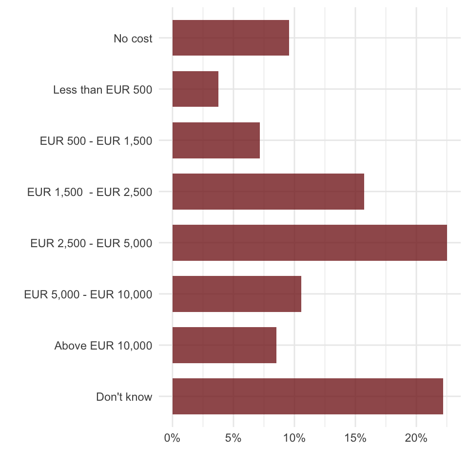

Figure 1: Cost of the Area B Policy

```r
data |>
  # dplyr::filter(target == 1) |> # Their code
  dplyr::filter(groups == "Diesel Euro 4") |>
  mutate(area_b_cost_fact = fct_rev(area_b_cost_fact)) |> # Reorder them
  ggplot() +
  aes(area_b_cost_fact) +
  geom_bar(
    aes(y = after_stat(count / sum(count))), # Make %
    fill = "#852525",
    position = "dodge",
    width = 0.7,
    alpha = 0.8
  ) +
  coord_flip() +
  labs(x = "", y = "") +
  scale_y_continuous(, labels = scales::label_percent()) + # Make axis in %
  theme_minimal()
```

## References

Colantone, Italo, Livio Di Lonardo, Yotam Margalit, and Marco Percoco. 2024. “The Political Consequences of Green Policies: Evidence from Italy.” *American Political Science Review* 118 (1): 108–26. https://doi.org/10.1017/S0003055423000308.